# Outcomes Factorial analysis

Francisco Villarroel

04-12-2020

## Proceso de validación de escala de posición política

En este documento daremos los principales resultados que arroja nuestro proceso de validación de escala de posición política, que será utilizada en nuestra encuesta experimental sobre la influencia de la homofilia y la posición política en las emociones en la esfera pública.

El informe está distribuído en tres partes: 1)test previos para ver si la escala es suceptible de ser apta para un análisis factorial, 2) Análisis factorial exploratorio y 3) Análisis factorial confirmatorio.

## Descripción de escala

```
##          apa    apaTables  GPArotation        psych   parameters psychometric
##         TRUE         TRUE         TRUE         TRUE         TRUE         TRUE
##       lavaan     nFactors      semPlot          MVN     semTools
##         TRUE         TRUE         TRUE         TRUE         TRUE
```

## Test de prueba

### Test de correlaciones

```r
load(file = "Pre-testing scales/Data/Processing/AFE.RData")

corr.test(AFE)
```

```
## Call:corr.test(x = AFE)
## Correlation matrix
##              esc_migra esc_abort esc_strate esc_const esc_rich esc_effort
## esc_migra         1.00      0.52       0.21      0.32     0.25       0.49
## esc_abort         0.52      1.00       0.33      0.56     0.43       0.40
## esc_strate        0.21      0.33       1.00      0.59     0.59       0.24
## esc_const         0.32      0.56       0.59      1.00     0.65       0.31
## esc_rich          0.25      0.43       0.59      0.65     1.00       0.40
## esc_effort        0.49      0.40       0.24      0.31     0.40       1.00
## esc_afp           0.29      0.46       0.57      0.56     0.65       0.35
## esc_policia       0.51      0.53       0.21      0.31     0.30       0.63
## esc_mapuche       0.39      0.52       0.49      0.63     0.58       0.39
## esc_autorita      0.46      0.47       0.27      0.40     0.39       0.51
##              esc_afp esc_policia esc_mapuche esc_autorita
## esc_migra       0.29        0.51        0.39         0.46
## esc_abort       0.46        0.53        0.52         0.47
## esc_strate      0.57        0.21        0.49         0.27
## esc_const       0.56        0.31        0.63         0.40
## esc_rich        0.65        0.30        0.58         0.39
## esc_effort      0.35        0.63        0.39         0.51
## esc_afp         1.00        0.31        0.60         0.34
## esc_policia     0.31        1.00        0.38         0.56
## esc_mapuche     0.60        0.38        1.00         0.43
## esc_autorita    0.34        0.56        0.43         1.00
## Sample Size
## [1] 214
## Probability values (Entries above the diagonal are adjusted for multiple tests.)
##              esc_migra esc_abort esc_strate esc_const esc_rich esc_effort
## esc_migra            0         0          0         0        0          0
## esc_abort            0         0          0         0        0          0
## esc_strate           0         0          0         0        0          0
## esc_const            0         0          0         0        0          0
## esc_rich             0         0          0         0        0          0
## esc_effort           0         0          0         0        0          0
## esc_afp              0         0          0         0        0          0
## esc_policia          0         0          0         0        0          0
## esc_mapuche          0         0          0         0        0          0
## esc_autorita         0         0          0         0        0          0
##              esc_afp esc_policia esc_mapuche esc_autorita
## esc_migra          0           0           0            0
## esc_abort          0           0           0            0
## esc_strate         0           0           0            0
## esc_const          0           0           0            0
## esc_rich           0           0           0            0
## esc_effort         0           0           0            0
## esc_afp            0           0           0            0
## esc_policia        0           0           0            0
## esc_mapuche        0           0           0            0
## esc_autorita       0           0           0            0
##
##  To see confidence intervals of the correlations, print with the short=FALSE option
```

como vemos en los resultados, las variables parecieran estar correlacionadas y en la significancia estadística es menos al 0.05

### Barlett test

Para ir un poco más allá utilizamos el test de barlett para observar la esfericidad de la escala

```r
correlaciones <-corr.test(AFE)
correlaciones$r
```

```
##              esc_migra esc_abort esc_strate esc_const  esc_rich esc_effort
## esc_migra    1.0000000 0.5179784  0.2050824 0.3218552 0.2530394  0.4920569
## esc_abort    0.5179784 1.0000000  0.3293963 0.5619397 0.4308907  0.4023357
## esc_strate   0.2050824 0.3293963  1.0000000 0.5877169 0.5899844  0.2363697
## esc_const    0.3218552 0.5619397  0.5877169 1.0000000 0.6535846  0.3142310
## esc_rich     0.2530394 0.4308907  0.5899844 0.6535846 1.0000000  0.4010822
## esc_effort   0.4920569 0.4023357  0.2363697 0.3142310 0.4010822  1.0000000
## esc_afp      0.2853242 0.4587650  0.5688977 0.5570061 0.6514594  0.3509680
## esc_policia  0.5113954 0.5293939  0.2136166 0.3094408 0.2993658  0.6267827
## esc_mapuche  0.3891605 0.5166419  0.4879037 0.6296561 0.5803644  0.3944166
## esc_autorita 0.4572881 0.4748475  0.2723257 0.4036889 0.3942151  0.5078569
##                esc_afp esc_policia esc_mapuche esc_autorita
## esc_migra    0.2853242   0.5113954   0.3891605    0.4572881
## esc_abort    0.4587650   0.5293939   0.5166419    0.4748475
## esc_strate   0.5688977   0.2136166   0.4879037    0.2723257
## esc_const    0.5570061   0.3094408   0.6296561    0.4036889
## esc_rich     0.6514594   0.2993658   0.5803644    0.3942151
## esc_effort   0.3509680   0.6267827   0.3944166    0.5078569
## esc_afp      1.0000000   0.3090786   0.6005326    0.3399639
## esc_policia  0.3090786   1.0000000   0.3842255    0.5564789
## esc_mapuche  0.6005326   0.3842255   1.0000000    0.4262173
## esc_autorita 0.3399639   0.5564789   0.4262173    1.0000000
```

```r
r<-as.matrix(correlaciones$r)
cortest.bartlett(r, n=214)
```

```
## $chisq
## [1] 1031.164
##
## $p.value
## [1] 1.099959e-186
##
## $df
## [1] 45
```

Vemos que el p-valor es bastante menos de 0.005 por lo tanto esta escala está apta para ser suceptible de análisis factorial

###KMO test

```r
KMO(AFE)
```

```
## Kaiser-Meyer-Olkin factor adequacy
## Call: KMO(r = AFE)
## Overall MSA =  0.89
## MSA for each item =
##    esc_migra    esc_abort   esc_strate    esc_const     esc_rich   esc_effort
##         0.90         0.89         0.90         0.88         0.88         0.85
##      esc_afp  esc_policia  esc_mapuche esc_autorita
##         0.90         0.84         0.93         0.93
```

Según lo que señalan estos test, esta escala tiene las características necesarias para ser sometida a análisis factorial. Haremos primero el análisis Factorial Exploratorio y luego daremos los resultados del confirmatorio, tanto para un factor como para dos.

## Análisis factorial exploratorio

Se ha resuelto por usar un método de rotación oblicuo, donde hemos probado distintos modelos sin tener mayores diferencias de resultados.

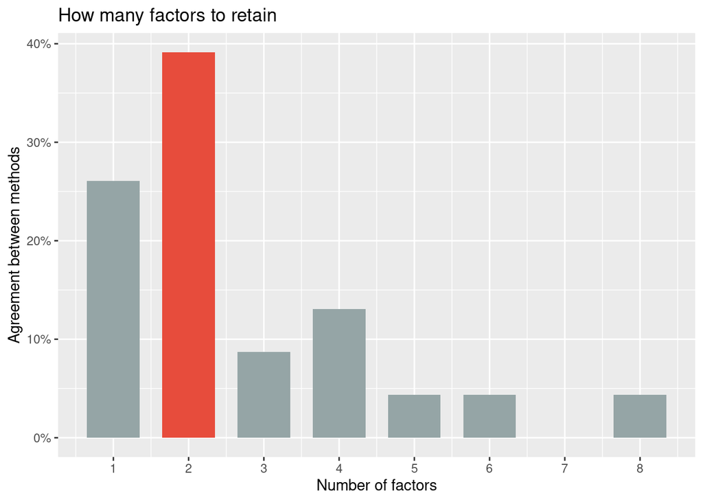

```r
results_nfactorASI<-n_factors(AFE, rotate = "Promax", fm = "mle", n = NULL)
plot(results_nfactorASI)
```

```r
results_nfactorASI
```

```
## # Method Agreement Procedure:
##
## The choice of 2 dimensions is supported by 9 (39.13%) methods out of 23 (Optimal coordinates, Parallel analysis, Kaiser criterion, SE Scree, R2, VSS complexity 2, Velicer's MAP, BIC, BIC).
```

```r
as.data.frame(results_nfactorASI)
```

```
##    n_Factors              Method              Family
## 1          1             Bentler             Bentler
## 2          1                   t Multiple_regression
## 3          1                   p Multiple_regression
## 4          1 Acceleration factor               Scree
## 5          1    VSS complexity 1                 VSS
## 6          1               RMSEA                 Fit
## 7          2 Optimal coordinates               Scree
## 8          2   Parallel analysis               Scree
## 9          2    Kaiser criterion               Scree
## 10         2            SE Scree            Scree_SE
## 11         2                  R2            Scree_SE
## 12         2    VSS complexity 2                 VSS
## 13         2       Velicer's MAP        Velicers_MAP
## 14         2                 BIC                 BIC
## 15         2                 BIC                 Fit
## 16         3                 CNG                 CNG
## 17         3      BIC (adjusted)                 BIC
## 18         4            Bartlett             Barlett
## 19         4                beta Multiple_regression
## 20         4                CRMS                 Fit
## 21         5            Anderson             Barlett
## 22         6                 TLI                 Fit
## 23         8              Lawley             Barlett
```

```r
summary(results_nfactorASI)
```

```
##   n_Factors n_Methods
## 1         1         6
## 2         2         9
## 3         3         2
## 4         4         3
## 5         5         1
## 6         6         1
## 7         8         1
```

Como vemos, el proceso para analizar cuántos factores tenemos muestra que tenemos 2. Puede que ambos factores sean “Izquierda” y “Derecha”?

Para ver el nivel de correlación de ellos observemos el análisis factorial exploratorio:

```r
ASIfactor<-fa(AFE,nfactors = 2,fm = "ml",rotate ="Promax",cor = "poly")
print(ASIfactor,digits = 2,cut = .40,sort=TRUE)
```

```
## Factor Analysis using method =  ml
## Call: fa(r = AFE, nfactors = 2, rotate = "Promax", fm = "ml", cor = "poly")
## Standardized loadings (pattern matrix) based upon correlation matrix
##              item   ML1   ML2   h2   u2 com
## esc_strate      3  0.89       0.64 0.36 1.1
## esc_rich        5  0.87       0.78 0.22 1.0
## esc_const       4  0.86       0.74 0.26 1.0
## esc_afp         7  0.85       0.68 0.32 1.0
## esc_mapuche     9  0.68       0.67 0.33 1.2
## esc_policia     8        0.99 0.79 0.21 1.1
## esc_effort      6        0.77 0.61 0.39 1.0
## esc_migra       1        0.73 0.51 0.49 1.0
## esc_autorita   10        0.71 0.60 0.40 1.0
## esc_abort       2        0.56 0.66 0.34 1.6
##
##                        ML1  ML2
## SS loadings           3.66 3.02
## Proportion Var        0.37 0.30
## Cumulative Var        0.37 0.67
## Proportion Explained  0.55 0.45
## Cumulative Proportion 0.55 1.00
##
##  With factor correlations of
##      ML1  ML2
## ML1 1.00 0.63
## ML2 0.63 1.00
##
## Mean item complexity =  1.1
## Test of the hypothesis that 2 factors are sufficient.
##
## The degrees of freedom for the null model are  45  and the objective function was  7.36 with Chi Square of  1537.13
## The degrees of freedom for the model are 26  and the objective function was  0.57
##
## The root mean square of the residuals (RMSR) is  0.04
## The df corrected root mean square of the residuals is  0.05
##
## The harmonic number of observations is  214 with the empirical chi square  23.62  with prob <  0.6
## The total number of observations was  214  with Likelihood Chi Square =  118.3  with prob <  9.8e-14
##
## Tucker Lewis Index of factoring reliability =  0.892
## RMSEA index =  0.129  and the 90 % confidence intervals are  0.106 0.153
## BIC =  -21.22
## Fit based upon off diagonal values = 1
## Measures of factor score adequacy
##                                                    ML1  ML2
## Correlation of (regression) scores with factors   0.96 0.95
## Multiple R square of scores with factors          0.93 0.91
## Minimum correlation of possible factor scores     0.86 0.82
```

## Análisis factorial confirmatorio

Vamos a ver qué nos dice el confirmatorio. con él hicimos dos muestras: una como si fuese un sólo factor (que está al comienzo) y un segundo análisis que considera dos factores, siendo “left” y “right” sus etiquetas.

Recordar que este procedimiento se realiza con la base completa

```r
load(file = "Pre-testing scales/Data/Processing/scale.RData")

Onefactor<-'Ideol =~ esc_migra + esc_abort + esc_strate + esc_const + esc_rich + esc_effort
+ esc_afp + esc_policia + esc_mapuche + esc_autorita
'
Twofactor<-'Left =~ esc_rich + esc_strate + esc_afp + esc_const + esc_mapuche
Right =~ esc_policia + esc_autorita + esc_abort + esc_migra + esc_effort'

CFAone <- cfa(Onefactor,orthogonal=FALSE, data=DFscale, estimator="WLSMV",ordered =names(DFscale))
summary(CFAone, fit.measures=TRUE)
```

```
## lavaan 0.6-7 ended normally after 26 iterations
##
##   Estimator                                       DWLS
##   Optimization method                           NLMINB
##   Number of free parameters                         40
##
##   Number of observations                           299
##
## Model Test User Model:
##                                               Standard      Robust
##   Test Statistic                               225.083     298.401
##   Degrees of freedom                                35          35
##   P-value (Chi-square)                           0.000       0.000
##   Scaling correction factor                                  0.784
##   Shift parameter                                           11.404
##        simple second-order correction
##
## Model Test Baseline Model:
##
##   Test statistic                              6446.405    3207.874
##   Degrees of freedom                                45          45
##   P-value                                        0.000       0.000
##   Scaling correction factor                                  2.024
##
## User Model versus Baseline Model:
##
##   Comparative Fit Index (CFI)                    0.970       0.917
##   Tucker-Lewis Index (TLI)                       0.962       0.893
##
##   Robust Comparative Fit Index (CFI)                            NA
##   Robust Tucker-Lewis Index (TLI)                               NA
##
## Root Mean Square Error of Approximation:
##
##   RMSEA                                          0.135       0.159
##   90 Percent confidence interval - lower         0.118       0.143
##   90 Percent confidence interval - upper         0.152       0.176
##   P-value RMSEA <= 0.05                          0.000       0.000
##
##   Robust RMSEA                                                  NA
```

[output cut: 85 more lines]

```
##    .esc_autorita      0.406
##     Ideol             0.490    0.048   10.323    0.000
##
## Scales y*:
##                    Estimate  Std.Err  z-value  P(>|z|)
##     esc_migra         1.000
##     esc_abort         1.000
##     esc_strate        1.000
##     esc_const         1.000
##     esc_rich          1.000
##     esc_effort        1.000
##     esc_afp           1.000
##     esc_policia       1.000
##     esc_mapuche       1.000
##     esc_autorita      1.000
```

```r
CFAtworele <- cfa(Twofactor,orthogonal=FALSE, data=DFscale, estimator="WLSMV",ordered =names(DFscale))
summary(CFAtworele, fit.measures=TRUE)
```

```
## lavaan 0.6-7 ended normally after 22 iterations
##
##   Estimator                                       DWLS
##   Optimization method                           NLMINB
##   Number of free parameters                         41
##
##   Number of observations                           299
##
## Model Test User Model:
##                                               Standard      Robust
##   Test Statistic                                61.157     102.127
##   Degrees of freedom                                34          34
##   P-value (Chi-square)                           0.003       0.000
##   Scaling correction factor                                  0.653
##   Shift parameter                                            8.421
##        simple second-order correction
##
## Model Test Baseline Model:
##
##   Test statistic                              6446.405    3207.874
##   Degrees of freedom                                45          45
##   P-value                                        0.000       0.000
##   Scaling correction factor                                  2.024
##
## User Model versus Baseline Model:
##
##   Comparative Fit Index (CFI)                    0.996       0.978
##   Tucker-Lewis Index (TLI)                       0.994       0.971
##
##   Robust Comparative Fit Index (CFI)                            NA
##   Robust Tucker-Lewis Index (TLI)                               NA
##
## Root Mean Square Error of Approximation:
##
##   RMSEA                                          0.052       0.082
##   90 Percent confidence interval - lower         0.030       0.064
##   90 Percent confidence interval - upper         0.072       0.101
##   P-value RMSEA <= 0.05                          0.419       0.002
##
##   Robust RMSEA                                                  NA
```

[output cut: 93 more lines]

```
##     Left              0.695    0.049   14.116    0.000
##     Right             0.614    0.049   12.606    0.000
##
## Scales y*:
##                    Estimate  Std.Err  z-value  P(>|z|)
##     esc_rich          1.000
##     esc_strate        1.000
##     esc_afp           1.000
##     esc_const         1.000
##     esc_mapuche       1.000
##     esc_policia       1.000
##     esc_autorita      1.000
##     esc_abort         1.000
##     esc_migra         1.000
##     esc_effort        1.000
```

```r
fitMeasures(CFAtworele)
```

```
##                          npar                          fmin
##                        41.000                         0.102
##                         chisq                            df
##                        61.157                        34.000
##                        pvalue                  chisq.scaled
##                         0.003                       102.127
##                     df.scaled                 pvalue.scaled
##                        34.000                         0.000
##          chisq.scaling.factor                baseline.chisq
##                         0.653                      6446.405
##                   baseline.df               baseline.pvalue
##                        45.000                         0.000
##         baseline.chisq.scaled            baseline.df.scaled
##                      3207.874                        45.000
##        baseline.pvalue.scaled baseline.chisq.scaling.factor
##                         0.000                         2.024
##                           cfi                           tli
##                         0.996                         0.994
##                          nnfi                           rfi
##                         0.994                         0.987
##                           nfi                          pnfi
##                         0.991                         0.748
##                           ifi                           rni
##                         0.996                         0.996
##                    cfi.scaled                    tli.scaled
##                         0.978                         0.971
##                    cfi.robust                    tli.robust
##                            NA                            NA
##                   nnfi.scaled                   nnfi.robust
##                         0.971                            NA
##                    rfi.scaled                    nfi.scaled
##                         0.958                         0.968
##                    ifi.scaled                    rni.scaled
##                         0.979                         0.978
##                    rni.robust                         rmsea
##                            NA                         0.052
##                rmsea.ci.lower                rmsea.ci.upper
##                         0.030                         0.072
##                  rmsea.pvalue                  rmsea.scaled
##                         0.419                         0.082
##         rmsea.ci.lower.scaled         rmsea.ci.upper.scaled
##                         0.064                         0.101
##           rmsea.pvalue.scaled                  rmsea.robust
##                         0.002                            NA
##         rmsea.ci.lower.robust         rmsea.ci.upper.robust
##                            NA                            NA
##           rmsea.pvalue.robust                           rmr
##                            NA                         0.049
##                    rmr_nomean                          srmr
##                         0.053                         0.053
##                  srmr_bentler           srmr_bentler_nomean
##                         0.049                         0.053
##                          crmr                   crmr_nomean
##                         0.053                         0.059
##                    srmr_mplus             srmr_mplus_nomean
##                            NA                            NA
##                         cn_05                         cn_01
##                       237.824                       274.167
##                           gfi                          agfi
##                         0.994                         0.986
##                          pgfi                           mfi
##                         0.450                         0.955
```

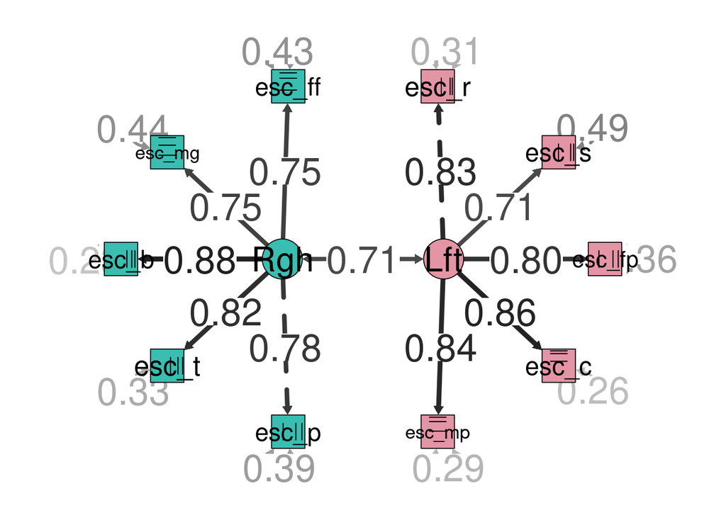

```r
semPaths(CFAtworele, intercepts = FALSE,edge.label.cex=2.5, optimizeLatRes = TRUE, groups = "lat",
         pastel = TRUE, exoVar = FALSE, sizeInt=5,edge.color ="black",esize = 6, label.prop=2,
         sizeLat = 6,"std", layout="circle2")
```

## Conclusiones

Son las siguientes

- Por lo visto en los pre-test, creo que la escala es apta para análisis confirmatorio
- No sé cómo interpretar lo de los dos factores descubiertos en el AFE. ¿Serán izquierda y derecha?
- Tanto para el AFE como el AFC, no sé cuáles de todos los cerros de indicadores son los más importantes que debo reportar
- En el pathanálysis que muestra la influencia de cada ítem en los factores, no sé cómo interpretar las líneas entrecortadas (significancia estadística?) y los números en gris oscuro.

¡Gracias!